# Case Study 2

GEOG-3440

Case studies provide you with an opportunity to use relevant workflows or real world data to answer Earth science questions. These are typically written in story problem form so humor me by jumping into character! Take time to carefully read and consider how to solve each problem.

*Note that code blocks in this html file can be shown or hidden by clicking on the* `Show` *or* `Hide` *buttons throughout the document, or selecting the* `Code > Show/Hide all` *at the top right.*

### **Avalanche Hazard**

You were hired as a consultant by the Utah Avalanche Center (UAC) to analyze historical avalanche observations in the state, spatially assess avalanche risk, and create avalanche hazard maps from UAC forecast information over part of the Wasatch mountains. Avalanche-related deaths are not uncommon in Utah, with one or more occurring each year in parts of the state. The UAC, Forest Service, and UDOT Avalanche Team work tirelessly during the winter season to keep the public safe through mitigation efforts (*sometimes firing live artillery at the mountain side*) and accurate avalanche forecasting in the region.

You will be using the [Utah Avalanche Center](https://utahavalanchecenter.org/) (UAC) for historical avalanche observations and forecasts.

- Learn more about how to read an avalanche forecast and interpret the daily updated *rose diagram* in the UAC [forecast tutorial](https://utahavalanchecenter.org/forecast/tutorial) section on the UAC site.

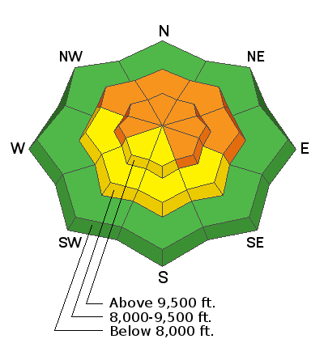

To properly understand conditions that lead to an avalanche, a UAC representative breaks down avalanche science. In the most basic sense, avalanches occur due to weak layers in the snowpack, which occur naturally throughout the season. With known weak layers, avalanche hazard can be predicted based on the slope, aspect, and elevation of any given terrain:

- Avalanches only occur on **slopes between 30-45 degrees**, due to forces of friction and gravity. This does not change over time, however, these slopes can be less hazardous once the snowpack stabilizes.
- Snowpack stability changes over time depending on *several meteorological factors*, such as new snow accumulation, temperature, windpeed, etc. These variables cause greater avalanche hazard across **varying aspects and elevations**.
- Dangerous aspects and elevations vary seasonally and even from day to day, depending on meteorological conditions. This is why the avalanche forecast must be **updated daily**, because snow stability can change rapidly!

*You will summarize existing avalanche oabservations and use the UAC forecast information to create an avalanche hazard map using DEM terrain analysis.*

**Your final report will consist of three parts** (*outlined in the sections below*)

1. **Historical Observations:** Summary of historical avalanche observations
2. **Spatial Risk Assessment:** Spatial assessment of avalanche risk across the state
3. **Avalanche Hazard Modeling:** Avalanche hazard mapping in the Central Wasatch
   - Taking chances in and around ski resort
   - Terrain modeling with UAC forecast data

Your results will be presented in a a single **final report** (*html*) complete with figures and maps to support your analysis.

*Expectations for each section of the report is outlined below, including a short* **Final Report** *statement at the end of the document.*

#### **Load in the Data**

Download this DEM that covers part of the Wasatch Range, along with Salt Lake and Utah Valley. This ASTER DEM is a remote sensing product with a resolution of ~30-meters spatial resolution and lists elevation in meters above sea level. If the link doesn’t work, copy/paste the url in a browser window: `https://github.com/mattols/geospat_data/raw/main/ASTGTM2_N40W112_dem.tif`.

Read in the following vector object showing the six main **ski resorts** near Salt Lake County:

```r
ski_shp <- vect("https://raw.githubusercontent.com/mattols/geospat_data/main/skiresorts_cottonwoods.geojson")
```

Load in reported **avalanche observations** from the UAC from 2012-2024:

```r
avy_df <- read.csv("https://raw.githubusercontent.com/mattols/geospat_data/main/avalanches_2012_2024.csv")
```

Load in a polygon feature of **Utah counties**:

```r
ut_cnty <- vect("https://github.com/mattols/geospat_data/raw/main/utah-counties.geojson")
```

### **Part 1. Historical Observations**

Load in the `avy_df` data frame. This file was downloaded from the UAC website on February 6th, 2024 and contains reported avalanche observations for the state of Utah.

Your first task is to perform a basic analysis of reported avalanches throughout the state. Fortunately, each observation already includes useful terrain observation.

**What stakeholders want to know about the historical record:**

- What are the most dangerous months of the year for avalanches?
- What are the most dangerous aspects? (*top three*)
- What is the range of elevation for avalanches in the state?
- What are the most common avalanche triggers?
- Are certain activities (triggers) more deadly or more likely to cause an avalanche?
- Are the total number of avalanches increasing each year? If so, is there a significant trend? (*keep in mind that the final year is not complete*)

Be sure to include a **detailed paragraph** outlining your summary of observations. Provide, at minimum, **two plots** to summarize the information above and support your description. Present the facts shown in the data but add an interpretation or discussion regarding your results as well.

*See the supplement for help and tips.*

### **Part 2. Spatial Risk Assessment**

You were mainly hired for this position because of your understanding of spatial analysis. Convert `avy_df` into a spatial vector object and read in the `ut_cnty` vector. Stakeholders are interested in understanding the reported incidents, including deaths and burials by county (i.e. you will summarize UAC observations within county units). Consider important aspects of spatial data as you perform this analysis.

Several factors may contribute to avalanche-related deaths. It is also possible that certain areas are more deadly than others. Assess which counties in the state have experienced the most avalanche fatalities, and estimate the likelihood of fatality (*risk*) if caught and if fully buried.

**What stakeholders want to know at the county level:**

- Which counties show the most fatalities (*Killed* column)
- Which counties have the highest probability of fatality if caught in an avalanche (assuming that fatalities are instances where individuals were caught)
- (*optional*) Consider calculating the probability of other scenarios (*e.g. frequency of being fully buried when caught in an avalanche*) by county.

Create a **single figure showing at least two map plots** side-by-side with the results above. Write **a few sentences** to summarize your takeaways and provide your interpretation of the results.

### **Part 3. Avalanche Hazard Modeling**

The final section will require you to perform terrain modeling to create avalanche hazard maps. First you will assess avalanche terrain in and around ski resorts, then you will create a hazard map from forecast data and compare it to observations.

#### **Part 3.1 Ski Resort Risk**

Read in the `ski_shp` layer and load the `dem` provided of the central Wasatch. Subset the dem to the extent of your ski resorts.

Stakeholders would like you to focus on assessing the terrain hazard in and around ski resorts in the Central Wasatch. With recent increases in individuals leaving resort boundaries (*including local university students*), managers are concerned about public safety and need to know which resorts are of greatest concern.

**What stakeholders want to know for ski resorts:**

- What is the percent of high risk avalanche terrain within each resort boundary?
  - Use the conditions from your results in Part 1 (i.e. top three most hazardous aspects) and also has a slope susceptible to avalanches.
- Describe which resort(s) might require the most avalanche mitigation work in and around the resort?
- Calculate the total area within 0.5 miles of each resort boundary (but outside of the resort) that has a slope susceptible to avalanches. *This is a useful consideration for individuals that may go out of bounds and is helpful for ski resort management*

Use the central Wasatch DEM to **create a map** showing areas of hazardous terrain (`"red"`) in and around ski resort boundaries shown (using top three hazardous aspects and slope conditions). Show a **second map** or **other plot** to show the percentage of each resort has a high risk of experiencing avalanches. Use the pixel count to convert to an area estimate in km^2. Alternatively, combine information from these two steps into a single map.

#### **Part 3.2 Real-Time Hazard Modeling**

Crop the extent of the DEM to the following: `xmin = -111.82, xmax = -111.53, ymin = 40.5, ymax = 40.7`. Stakeholders would like you to create several hazard maps based on the UAC forecast data to test the viability of predicting avalanche hazard in the Cottonwoods.

Fortunately, you received outside help from your old pal Dr. Olson to create a custom function that takes avalanche forecast data and a DEM to generate an avalanche hazard raster. To use the custom functions, you will need to load them into memory by calling `source("path_to_file/study2_functions.R")`. Look over each function in the file to understand how they work. You may edit these functions if you would like to make any changes. You can directly call the custom functions directly, and save the outputs:

```r
# create avalanche hazard model
hazard_raster <- UAC_forecast_hazard(dem, forecast_table, min_elv_ft)
# plot results
UAC_forecast_map(dem, hazard_raster, hill)
```

The `forecast_table` is updated based on the rose diagram provided in an avalanche forecast with values 1=“Low”, 2=“Moderate”, 3=“Considerable”, 4=“High”, 5=“Extreme” avalanche hazard. For each elevation, values in the first row begin with North and continue clockwise. For example:

```r
# example forecast
forecast_table <- data.frame(
  low = rep(1, 8), # specifying low hazard for all low elevations
  mid = c(2, 2, rep(1, 5), 2), # moderate hazard for mid elevation north slopes only (low on others)
  high = rep(3, 8)) # considerable hazard for all upper elevations

forecast_table
```

```
##   low mid high
## 1   1   2    3
## 2   1   2    3
## 3   1   1    3
## 4   1   1    3
## 5   1   1    3
## 6   1   1    3
## 7   1   1    3
## 8   1   2    3
```

Update the values in the forecast table based on the rose diagram in the UAC forecast.

**What stakeholders want to see:**

- Proof of concept avalanche hazard maps for:
  - [Feb 6, 2021](https://utahavalanchecenter.org/forecast/salt-lake/2/6/2021)
  - [Feb 11, 2021](https://utahavalanchecenter.org/forecast/salt-lake/2/11/2021)
  - For each, include historical oavalanche observation point data that are within two days of the dates listed above to assess the how well your hazard maps predict observed avalanches for those days
- Proof of concept for scalability:
  - Observe the forecasts and rose diagrams for each day over **Feb 11-18th**. Note that you can just change the dates in the url link (e.g. …org/…2/12/2021) or look through the [UAC archives](https://utahavalanchecenter.org/archives/forecasts).
  - Use a `for` loop (or other iterative process) to run your `UAC_forecast_hazard` function over this 7-day period and, for each day, extract the total area (in square kilometers) of avalanche terrain that is classified as considerable, high, and extreme. Create a plot showing how these values change over this week. Use `ggplot` and `geom_bar` with `fill` to group these categories into a single plot.
  - Subset the historical observation data over this same time period and assess whether observed avalanche patterns align with your terrain forecast hazard modeling over the course of this week

**You should now have enough information to write your final report.**

#### **Final Report**

> 1. Provide requested information from the historical observation data, including at least two plots and a detailed paragraph of your interpretation of the results.
> 2. Provide information about avalanche fatality and risk by county, including at least two map plots side-by-side with a short description.
> 3. Provide information about avalanche hazard modeling, including the two hazard maps, the figure or week-long changes in avalanche hazard, and a comparison of historical observations with the modeled hazard maps from UAC forecasts.
> 4. Summarize your conclusions with a brief paragraph that includes specific quantitative results (values) that you gathered in the steps above.

#### **Final Submission**

Upload a single, organized **report** for your stakeholders (**html**) written in **R Markdown**. Be sure to include requested items with **responses, figures, and maps**.

**Do not** include unnecessary code or details, make it a clean report!

*Please reach out if you have any questions!*